# Linear Model - Bodo Winter

This notebook walks through Bodo Winter’s tutorials on linear and mixed models in R Tutorial 1: http://www.bodowinter.com/tutorial/bw_LME_tutorial1.pdf Tutorial 2: http://www.bodowinter.com/tutorial/bw_LME_tutorial2.pdf

To execute code, click the *Run* button within the chunk or place your cursor inside it and pressing *Ctrl+Shift+Enter*.

```r
pitch = c(233, 204, 242, 130, 112, 142)
sex = c(rep("female",3), rep("male", 3))
my.df = data.frame(sex, pitch)
my.df
```

| sex | pitch |
| --- | --- |
| female | 233 |
| female | 204 |
| female | 242 |
| male | 130 |
| male | 112 |
| male | 142 |

Define our first linear model

```r
xmdl = lm(pitch ~ sex, my.df)
summary(xmdl)
```

```
Call:
lm(formula = pitch ~ sex, data = my.df)

Residuals:
      1       2       3       4       5       6
  6.667 -22.333  15.667   2.000 -16.000  14.000

Coefficients:
            Estimate Std. Error t value Pr(>|t|)
(Intercept)   226.33      10.18  22.224 2.43e-05 ***
sexmale       -98.33      14.40  -6.827  0.00241 **
---
Signif. codes:  0 ‘***’ 0.001 ‘**’ 0.01 ‘*’ 0.05 ‘.’ 0.1 ‘ ’ 1

Residual standard error: 17.64 on 4 degrees of freedom
Multiple R-squared:  0.921, Adjusted R-squared:  0.9012
F-statistic: 46.61 on 1 and 4 DF,  p-value: 0.002407
```

Learn notation for doing math on a subset of a dataframe

```r
mean(my.df[my.df$sex=="female",]$pitch)
```

```
[1] 226.3333
```

```r
mean(my.df[my.df$sex=="male",]$pitch)
```

```
[1] 128
```

Build a second linear model for pitch ~ age

```r
age = c(14, 23, 35, 48, 52, 67)
pitch = c(252, 244, 240, 233, 212, 204)
my.newdf = data.frame(age, pitch)
xmdl = lm(pitch ~ age, my.newdf)
summary(xmdl)
```

```
Call:
lm(formula = pitch ~ age, data = my.newdf)

Residuals:
     1      2      3      4      5      6
-2.338 -2.149  4.769  9.597 -7.763 -2.115

Coefficients:
            Estimate Std. Error t value Pr(>|t|)
(Intercept) 267.0765     6.8522   38.98 2.59e-06 ***
age          -0.9099     0.1569   -5.80  0.00439 **
---
Signif. codes:  0 ‘***’ 0.001 ‘**’ 0.01 ‘*’ 0.05 ‘.’ 0.1 ‘ ’ 1

Residual standard error: 6.886 on 4 degrees of freedom
Multiple R-squared:  0.8937,    Adjusted R-squared:  0.8672
F-statistic: 33.64 on 1 and 4 DF,  p-value: 0.004395
```

```r
dfbeta(xmdl)
```

```
  (Intercept)         age
1  -3.3645662  0.06437573
2  -1.6119656  0.02736278
3   1.5481303 -0.01456709
4  -0.0259835  0.05092767
5   0.8707699 -0.06479736
6   1.8551808 -0.06622744
```

Define a second linear model

```r
my.newdf$age.c = my.newdf$age - mean(my.newdf$age)
my.newdf$age.c
```

```
[1] -25.833333 -16.833333  -4.833333   8.166667  12.166667  27.166667
```

```r
xmdl = lm(pitch ~ age.c, my.newdf)
summary(xmdl)
```

```
Call:
lm(formula = pitch ~ age.c, data = my.newdf)

Residuals:
     1      2      3      4      5      6
-2.338 -2.149  4.769  9.597 -7.763 -2.115

Coefficients:
            Estimate Std. Error t value Pr(>|t|)
(Intercept) 230.8333     2.8113   82.11 1.32e-07 ***
age.c        -0.9099     0.1569   -5.80  0.00439 **
---
Signif. codes:  0 ‘***’ 0.001 ‘**’ 0.01 ‘*’ 0.05 ‘.’ 0.1 ‘ ’ 1

Residual standard error: 6.886 on 4 degrees of freedom
Multiple R-squared:  0.8937,    Adjusted R-squared:  0.8672
F-statistic: 33.64 on 1 and 4 DF,  p-value: 0.004395
```

Create a linear model with multiple predictors using some of the data already in our existing dataframes. Plot fitted vs. residuals and qqnorm plot of residuals.

```r
my.thirddf = data.frame(my.df$sex, my.newdf$age, my.newdf$pitch)
my.thirddf
```

| my.df.sex | my.newdf.age | my.newdf.pitch |
| --- | --- | --- |
| female | 14 | 252 |
| female | 23 | 244 |
| female | 35 | 240 |
| male | 48 | 233 |
| male | 52 | 212 |
| male | 67 | 204 |

```r
xmdl = lm(pitch ~ sex + age, my.thirddf)
summary(xmdl)
```

```
Call:
lm(formula = pitch ~ sex + age, data = my.thirddf)

Residuals:
     1      2      3      4      5      6
-2.221 -2.222  4.443  9.853 -7.592 -2.260

Coefficients:
            Estimate Std. Error t value Pr(>|t|)
(Intercept) 266.6646    10.3491  25.767 0.000128 ***
sexmale      -0.8546    13.8533  -0.062 0.954689
age          -0.8888     0.3865  -2.299 0.105039
---
Signif. codes:  0 ‘***’ 0.001 ‘**’ 0.01 ‘*’ 0.05 ‘.’ 0.1 ‘ ’ 1

Residual standard error: 7.946 on 3 degrees of freedom
Multiple R-squared:  0.8939,    Adjusted R-squared:  0.8231
F-statistic: 12.63 on 2 and 3 DF,  p-value: 0.03458
```

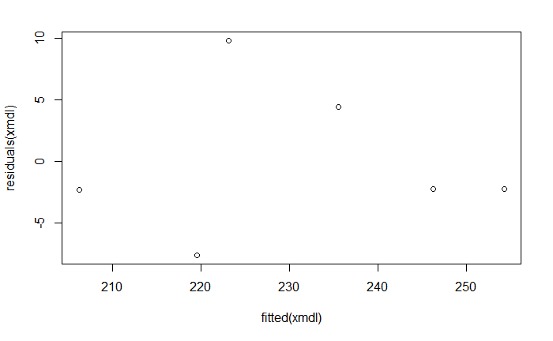

```r
plot(fitted(xmdl), residuals(xmdl))
```

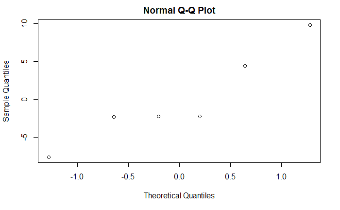

```r
qqnorm(residuals(xmdl))
```

***********NOW SWITCHING TO TUTORIAL 2****************

First we need to install lme4 package:

```r
install.packages("lme4")
library(lme4)
```

Cool. Now we have the functoin lmer() available to us, which is similar to lm() from Tutorial 1.

Let’s load the data from Bodo Winter’s server:

```r
politeness=
read.csv("http://www.bodowinter.com/tutorial/politeness_data.csv")
summary(politeness)
```

```
 subject gender    scenario attitude   frequency
 F1:14   F:42   Min.   :1   inf:42   Min.   : 82.2
 F2:14   M:42   1st Qu.:2   pol:42   1st Qu.:131.6
 F3:14          Median :4            Median :203.9
 M3:14          Mean   :4            Mean   :193.6
 M4:14          3rd Qu.:6            3rd Qu.:248.6
 M7:14          Max.   :7            Max.   :306.8
                                     NA's   :1
```

```r
politeness
```

| subject | gender | scenario | attitude | frequency |
| --- | --- | --- | --- | --- |
| F1 | F | 1 | pol | 213.3 |
| F1 | F | 1 | inf | 204.5 |
| F1 | F | 2 | pol | 285.1 |
| F1 | F | 2 | inf | 259.7 |
| F1 | F | 3 | pol | 203.9 |
| F1 | F | 3 | inf | 286.9 |
| F1 | F | 4 | pol | 250.8 |
| F1 | F | 4 | inf | 276.8 |
| F1 | F | 5 | pol | 231.9 |
| F1 | F | 5 | inf | 252.4 |

[output cut: 74 more lines]

Let’s see what data are missing:

```r
which(is.na(politeness$frequency))
```

```
[1] 39
```

```r
which(!complete.cases(politeness))
```

```
[1] 39
```

We are planning to use gender and attitude as our “fixed effects” and scenario and subject as our “random effects”. Let’s see how things look for our fixed effects by making box plots by attitude and gender:

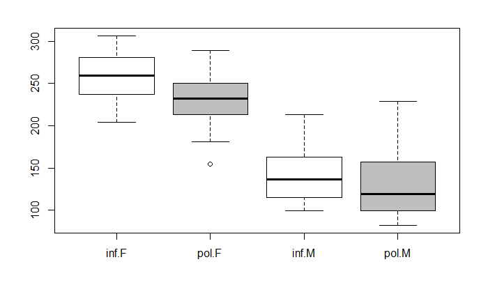

```r
boxplot(frequency ~ attitude*gender, col=c("white","gray"), politeness)
```

Looks like gender makes a big difference, but informal vs. polite might make a difference as well.

Let’s learn how to use the lmer function:

```r
?lmer
```

See information in the help section to the right - we can also just enter directly into that search box.

If we try to use lmer to create a linear model with no random effects, we get an error:

```r
lmer(frequency ~ attitude, data=politeness)
```

```
Error: No random effects terms specified in formula
```

We add random effects terms with the syntax: (1|variable). So let’s add our random effects in (subject and scenario):

```r
politeness.model = lmer(frequency ~ attitude + gender + (1|subject) + (1|scenario), data=politeness)
summary(politeness.model)
```

```
Linear mixed model fit by REML ['lmerMod']
Formula: frequency ~ attitude + gender + (1 | subject) + (1 | scenario)
   Data: politeness

REML criterion at convergence: 775.5

Scaled residuals:
    Min      1Q  Median      3Q     Max
-2.2591 -0.6236 -0.0772  0.5388  3.4795

Random effects:
 Groups   Name        Variance Std.Dev.
 scenario (Intercept) 219.5    14.81
 subject  (Intercept) 615.6    24.81
 Residual             645.9    25.41
Number of obs: 83, groups:  scenario, 7; subject, 6

Fixed effects:
            Estimate Std. Error t value
(Intercept)  256.846     16.116  15.938
attitudepol  -19.721      5.584  -3.532
genderM     -108.516     21.013  -5.164

Correlation of Fixed Effects:
            (Intr) atttdp
attitudepol -0.173
genderM     -0.652  0.004
```

Cool. Looks like attitude (polite or informal) had an effect on pitch, but how do we test for signficance? The plan is to create this model with and without attitude as a fixed effect and then do an anova comparing the two models. Note for reasons that I don’t fully understand, we have to say REML=false, which will optimize the log-likelihood criterion instead of the REML criterion.

```r
politeness.null = lmer(frequency ~ gender + (1|subject) + (1|scenario), data = politeness, REML=FALSE)
politeness.model = lmer(frequency ~ attitude + gender + (1|subject) + (1|scenario), data = politeness, REML=FALSE)
anova(politeness.null, politeness.model)
```

```
Data: politeness
Models:
politeness.null: frequency ~ gender + (1 | subject) + (1 | scenario)
politeness.model: frequency ~ attitude + gender + (1 | subject) + (1 | scenario)
                 Df    AIC    BIC  logLik deviance  Chisq Chi Df Pr(>Chisq)
politeness.null   5 816.72 828.81 -403.36   806.72
politeness.model  6 807.10 821.61 -397.55   795.10 11.618      1  0.0006532 ***
---
Signif. codes:  0 ‘***’ 0.001 ‘**’ 0.01 ‘*’ 0.05 ‘.’ 0.1 ‘ ’ 1
```

Nice - so with p = 0.0006532, we can say that adding attitude to the model is significant.

Let’s look at what our mixed model did with coefficients:

```r
coef(politeness.model)
```

```
$scenario
  (Intercept) attitudepol   genderM
1    243.4859   -19.72207 -108.5173
2    263.3592   -19.72207 -108.5173
3    268.1322   -19.72207 -108.5173
4    277.2546   -19.72207 -108.5173
5    254.9319   -19.72207 -108.5173
6    244.8015   -19.72207 -108.5173
7    245.9618   -19.72207 -108.5173

$subject
   (Intercept) attitudepol   genderM
F1    243.3684   -19.72207 -108.5173
F2    266.9443   -19.72207 -108.5173
F3    260.2276   -19.72207 -108.5173
M3    284.3536   -19.72207 -108.5173
M4    262.0575   -19.72207 -108.5173
M7    224.1292   -19.72207 -108.5173

attr(,"class")
[1] "coef.mer"
```

If we look at the coefficients, we see that we have a “random intercept” assigned for each scenario and each subject. However, the coefficients for the fixed effects variabes remained constant. However, it’s possible that the effect of attitude differs by subject or scenario, i.e. one subject may change their pitch more for a polite vs. informal statement compared to someone else. We may want to allow for “random slope” - where the slope can differ by subject and/or by scenario. We can do that by altering each random effect to account for differences in attitude:

```r
politeness.RandSlopeModel = lmer(frequency ~ attitude + gender + (1+attitude|subject) + (1+attitude|scenario), data=politeness, REML=FALSE)
summary(politeness.RandSlopeModel)
```

```
Linear mixed model fit by maximum likelihood  ['lmerMod']
Formula: frequency ~ attitude + gender + (1 + attitude | subject) + (1 +      attitude | scenario)
   Data: politeness

     AIC      BIC   logLik deviance df.resid
   814.9    839.1   -397.4    794.9       73

Scaled residuals:
    Min      1Q  Median      3Q     Max
-2.1947 -0.6691 -0.0789  0.5256  3.4252

Random effects:
 Groups   Name        Variance Std.Dev. Corr
 scenario (Intercept) 182.082  13.494
          attitudepol  31.262   5.591   0.22
 subject  (Intercept) 392.474  19.811
          attitudepol   1.707   1.307   1.00
 Residual             627.880  25.058
Number of obs: 83, groups:  scenario, 7; subject, 6

Fixed effects:
            Estimate Std. Error t value
(Intercept)  257.989     13.529  19.069
attitudepol  -19.747      5.922  -3.334
genderM     -110.802     17.512  -6.327

Correlation of Fixed Effects:
            (Intr) atttdp
attitudepol -0.105
genderM     -0.647  0.003
```

```r
coef(politeness.RandSlopeModel)
```

```
$scenario
  (Intercept) attitudepol   genderM
1    245.2603   -20.43832 -110.8021
2    263.3012   -15.94385 -110.8021
3    269.1432   -20.63361 -110.8021
4    276.8309   -16.30132 -110.8021
5    256.0579   -19.40575 -110.8021
6    246.8605   -21.94816 -110.8021
7    248.4702   -23.55752 -110.8021

$subject
   (Intercept) attitudepol   genderM
F1    243.8053   -20.68245 -110.8021
F2    266.7321   -19.17028 -110.8021
F3    260.1484   -19.60452 -110.8021
M3    285.6958   -17.91950 -110.8021
M4    264.1982   -19.33741 -110.8021
M7    227.3551   -21.76744 -110.8021

attr(,"class")
[1] "coef.mer"
```

And now to complete the significance testing, we need the same model without attitude as a fixed effect, but still included as a random slope for the random effects:

```r
politeness.RandSlopeNull = lmer(frequency ~ gender + (1+attitude|subject) + (1+attitude|scenario), data=politeness, REML=FALSE)
anova(politeness.RandSlopeNull, politeness.RandSlopeModel)
```

```
Data: politeness
Models:
politeness.RandSlopeNull: frequency ~ gender + (1 + attitude | subject) + (1 + attitude |
politeness.RandSlopeNull:     scenario)
politeness.RandSlopeModel: frequency ~ attitude + gender + (1 + attitude | subject) + (1 +
politeness.RandSlopeModel:     attitude | scenario)
                          Df    AIC    BIC  logLik deviance  Chisq Chi Df Pr(>Chisq)
politeness.RandSlopeNull   9 819.61 841.37 -400.80   801.61
politeness.RandSlopeModel 10 814.90 839.09 -397.45   794.90 6.7082      1   0.009597 **
---
Signif. codes:  0 ‘***’ 0.001 ‘**’ 0.01 ‘*’ 0.05 ‘.’ 0.1 ‘ ’ 1
```

Significant still at p= 0.009597. Nice.

Note in our baby monitor study, we will have random effect of subject, fixed effects of skin pigmentation and age. It is unlikely that any subject has different bias in pulse ox or pulse rate by skin pigmentation or age compared to another subject. Thus, it probably does NOT make sense to include random slopes in our analysis.

Ok, we still need to check some of our assumptions for any linear model.

Let’s look at a plot of fitted vs. residuals and a qqnorm plot of residuals to look for homoskedasticity and normality of residuals (although the latter is not so important):

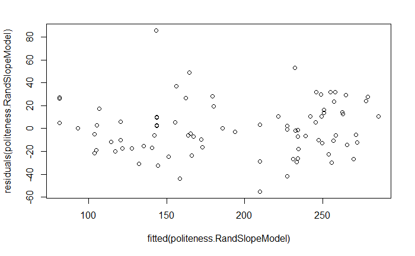

```r
plot(fitted(politeness.RandSlopeModel), residuals(politeness.RandSlopeModel))
```

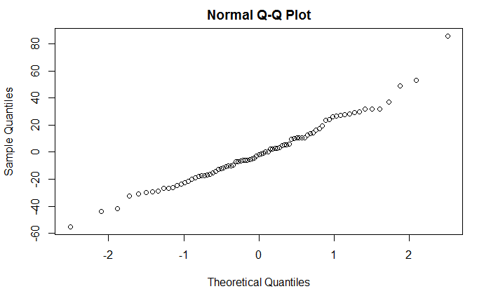

```r
qqnorm(residuals(politeness.RandSlopeModel))
```

Looks good!

```r
fixef(politeness.RandSlopeModel)[2]
```

```
attitudepol
  -19.74693
```

```r
politeness[-3,]
```

|  | subject | gender | scenario | attitude | frequency |
| --- | --- | --- | --- | --- | --- |
| 1 | F1 | F | 1 | pol | 213.3 |
| 2 | F1 | F | 1 | inf | 204.5 |
| 4 | F1 | F | 2 | inf | 259.7 |
| 5 | F1 | F | 3 | pol | 203.9 |
| 6 | F1 | F | 3 | inf | 286.9 |
| 7 | F1 | F | 4 | pol | 250.8 |
| 8 | F1 | F | 4 | inf | 276.8 |
| 9 | F1 | F | 5 | pol | 231.9 |
| 10 | F1 | F | 5 | inf | 252.4 |
| 11 | F1 | F | 6 | pol | 181.2 |

[output cut: 73 more lines]

Let’s look for influential data points by looping through the data, leaving one data point out at time, and seeing the impact on coefficients:

```r
all.res = numeric(nrow(politeness))
for (i in 1:nrow(politeness)){
  thisModel = lmer(frequency ~ attitude + gender + (1+attitude|subject) + (1+attitude|scenario), data=politeness[-i,], REML=FALSE)
  all.res[i] = fixef(thisModel)[2]
}
all.res
```

```
 [1] -19.85270 -20.53290 -21.27598 -19.41852 -18.88568 -18.79709 -19.90213 -19.33105 -20.04197 -19.44344 -18.82830 -19.79877 -20.28007
[14] -18.12146 -19.82172 -20.04663 -19.35904 -20.17991 -20.23374 -19.91470 -20.10660 -18.93796 -19.56735 -19.90751 -19.72394 -18.93874
[27] -19.33956 -18.49938 -19.42412 -20.21346 -22.39052 -20.92632 -18.69750 -18.43504 -20.90216 -20.00151 -18.77163 -20.38929 -19.74693
[40] -19.89745 -19.68803 -19.94389 -19.89153 -19.89261 -19.05906 -20.29059 -19.15191 -20.31863 -19.14477 -20.21141 -19.76173 -20.08802
[53] -20.71438 -19.66666 -19.20750 -20.61454 -19.70397 -20.42012 -19.42994 -20.11863 -20.71116 -19.02271 -18.96011 -19.43337 -20.65126
[66] -18.90177 -18.89499 -20.55696 -19.04438 -19.52820 -20.06088 -18.87073 -18.96071 -19.09913 -19.52320 -19.74623 -20.59703 -19.83773
[79] -19.90478 -20.24511 -19.85235 -19.91273 -19.88473 -20.06156
```

```r
which.max(all.res)
```

```
[1] 14
```

```r
max(all.res)
```

```
[1] -18.12146
```

```r
which.min(all.res)
```

```
[1] 31
```

```r
min(all.res)
```

```
[1] -22.39052
```

No single point appears to be wildly influential.